# MB5370: Techniques in Marine Science 1

# Module 1 - Workshop 04. The Developer’s Toolbox & AI

## Step 1: Prepare Your Workspace

Load needed packages

```r
library(tidyverse)
library(palmerpenguins)
```

## Step 2: Prompt for a Multi-Variable Scatter Plot

#### Create a ggplot scatter plot using the penguins dataset. Plot bill_length_mm on the x-axis and bill_depth_mm on the y-axis. Color points by species and use geom_point with size 3. Add a minimal theme and clean labels.

Filter out rows with missing values for the plotted variables

```r
penguins_clean <- subset(penguins,
                         !is.na(bill_length_mm) &
                         !is.na(bill_depth_mm) &
                         !is.na(species))
```

Plot data

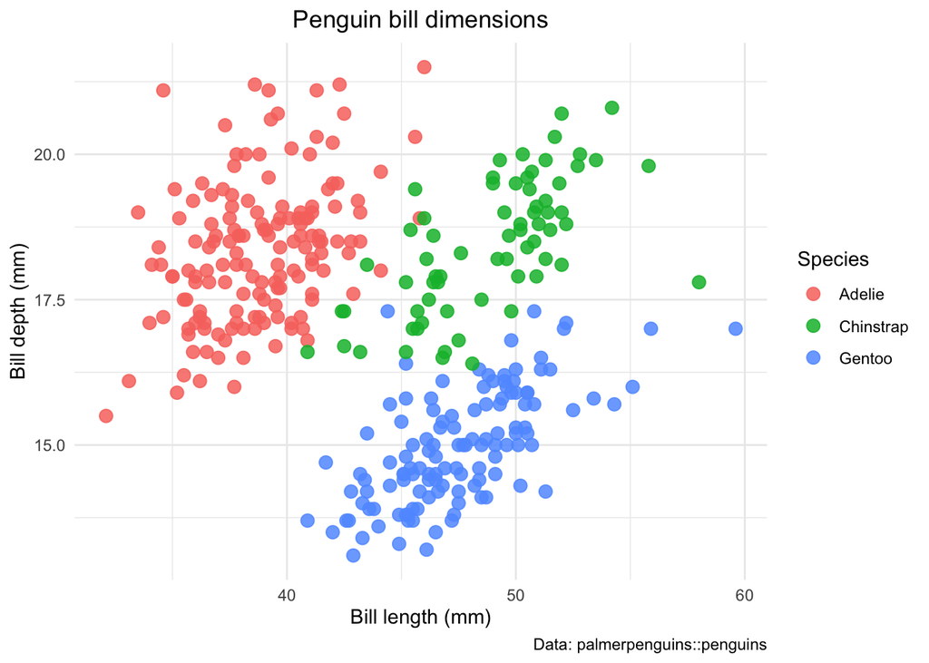

```r
ggplot(penguins_clean, aes(x = bill_length_mm, y = bill_depth_mm, color = species)) +
  geom_point(size = 3, alpha = 0.85) +
  theme_minimal() +
  labs(
    title = "Penguin bill dimensions",
    x = "Bill length (mm)",
    y = "Bill depth (mm)",
    color = "Species",
    caption = "Data: palmerpenguins::penguins"
  ) +
  theme(
    plot.title = element_text(hjust = 0.5),
    legend.position = "right"
  )
```

## Step 3: Open-Ended Comparative Plotting

#### Option A (Distribution Check): Instruct Copilot to generate a boxplot comparing flipper_length_mm across different species, faceted by island, using custom color palettes.

Filter out rows with missing values for the plotted variables

```r
penguins_clean <- subset(penguins,
                         !is.na(flipper_length_mm) &
                         !is.na(species) &
                         !is.na(island))
```

Define a custom palette (map species names to specific colors)

```r
species_colors <- c(
  "Adelie"    = "#1f78b4",  # blue
  "Chinstrap" = "#33a02c",  # green
  "Gentoo"    = "#e31a1c"   # red
)
```

Create the boxplot: flipper_length_mm by species, faceted by island

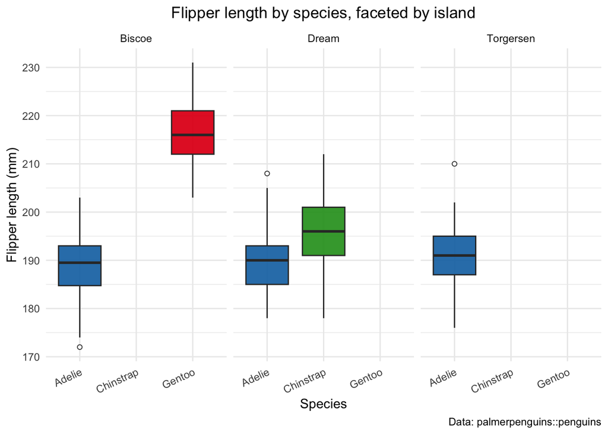

```r
ggplot(penguins_clean, aes(x = species, y = flipper_length_mm, fill = species)) +
  geom_boxplot(outlier.shape = 21, outlier.fill = "white", alpha = 0.95) +
  scale_fill_manual(values = species_colors) +
  facet_wrap(~ island) +
  theme_minimal() +
  labs(
    title = "Flipper length by species, faceted by island",
    x = "Species",
    y = "Flipper length (mm)",
    fill = "Species",
    caption = "Data: palmerpenguins::penguins"
  ) +
  theme(
    plot.title = element_text(hjust = 0.5),
    axis.text.x = element_text(angle = 25, hjust = 1),
    legend.position = "none"
  )
```

#### Option B (Biomass Correlation): Instruct Copilot to build a scatter plot mapping body_mass_g against flipper_length_mm, adding a linear regression trend line (geom_smooth) for each species.

Filter out rows with missing values for the plotted variables

```r
penguins_clean <- subset(penguins,
                         !is.na(flipper_length_mm) &
                         !is.na(body_mass_g) &
                         !is.na(species))
```

Define a custom palette

```r
species_colors <- c(
  "Adelie"    = "#1f78b4",
  "Chinstrap" = "#33a02c",
  "Gentoo"    = "#e31a1c"
)
```

Scatter plot: flipper_length_mm (x) vs body_mass_g (y), points colored by species Add a linear regression trend line (geom_smooth) for each species

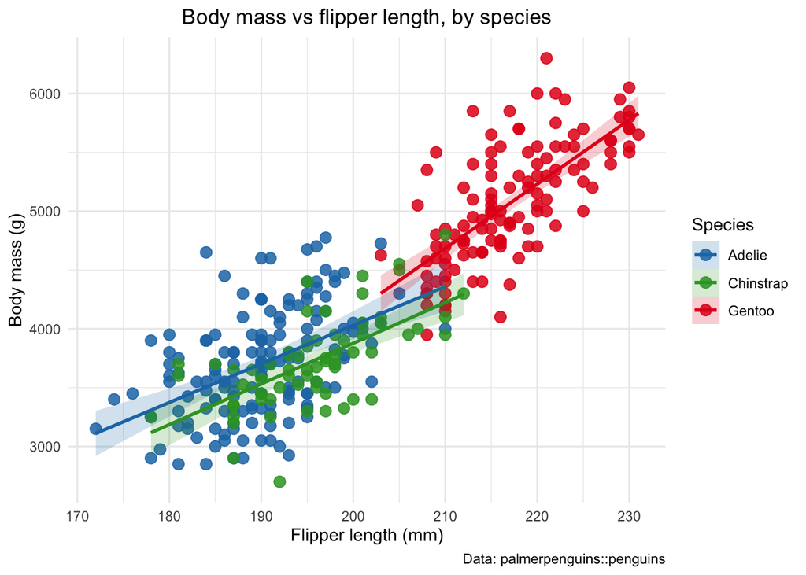

```r
ggplot(penguins_clean, aes(x = flipper_length_mm, y = body_mass_g, color = species)) +
  geom_point(size = 3, alpha = 0.85) +
  geom_smooth(aes(fill = species), method = "lm", formula = y ~ x, se = TRUE, alpha = 0.2) +
  scale_color_manual(values = species_colors) +
  scale_fill_manual(values = species_colors) +
  theme_minimal() +
  labs(
    title = "Body mass vs flipper length, by species",
    x = "Flipper length (mm)",
    y = "Body mass (g)",
    color = "Species",
    fill = "Species",
    caption = "Data: palmerpenguins::penguins"
  ) +
  theme(
    plot.title = element_text(hjust = 0.5),
    legend.position = "right"
  )
```

# chattr (Conversational Workspace Engine)

Load needed packages

```r
# install.packages("ellmer")
```

```r
# install.packages("chattr")
```

```r
# usethis::edit_r_environ()
```

```r
# usethis::edit_r_profile()
```

```r
# options(.chattr_chat = ellmer::chat_google_gemini())
```

Simple Example: Checking Sea Surface Temperature (SST)

```r
sst <- 30.2

if (sst > 29.5) {
  print("Warning: Marine heatwave threshold exceeded!")
} else {
  print("SST remains within baseline parameters.")
}
```

```
## [1] "Warning: Marine heatwave threshold exceeded!"
```

Sample coral data

```r
coral_monitoring <- tibble(
  site = c("Site_A", "Site_B", "Site_C"),
  depth_m = c(12, 35, 8)
)
```

Classify depth using if_else

```r
coral_monitoring <- coral_monitoring %>%
  mutate(zone = if_else(depth_m > 30, "Deep Reef", "Shallow Reef"))
```

```r
coral_monitoring <- coral_monitoring %>%
  mutate(reef_category = case_when(
    depth_m < 10  ~ "Lagoon / Flats",
    depth_m <= 30 ~ "Crest / Slope",
    depth_m > 30  ~ "Mesophotic / Deep",
    TRUE          ~ "Unclassified" # Catch-all remainder
  ))
```

## Environmental Stress Classification Task

Initialize the tibble

```r
marine_stations <- tibble(
  salinity = c(35, 28, 32, 12)
)
```

Add environment_type using pipe + mutate + case_when

```r
marine_stations <- marine_stations %>%
  mutate(
    environment_type = case_when(
      salinity < 15 ~ "Estuarine",
      salinity >= 15 & salinity <= 30 ~ "Brackish",
      salinity > 30 ~ "Marine"
    )
  )
```

Verify structure

```r
print(marine_stations)
```

```
## # A tibble: 4 × 2
##   salinity environment_type
##      <dbl> <chr>
## 1       35 Marine
## 2       28 Brackish
## 3       32 Marine
## 4       12 Estuarine
```

```r
str(marine_stations)
```

```
## tibble [4 × 2] (S3: tbl_df/tbl/data.frame)
##  $ salinity        : num [1:4] 35 28 32 12
##  $ environment_type: chr [1:4] "Marine" "Brackish" "Marine" "Estuarine"
```

## Automation — Iterating Efficiently

#### Base R: for-loops

A for-loop repeats a code chunk for each element in a designated sequence.

Classic loop anatomy

```r
for (year in 2020:2024) {
  print(paste("Processing climate data for year:", year))
}
```

```
## [1] "Processing climate data for year: 2020"
## [1] "Processing climate data for year: 2021"
## [1] "Processing climate data for year: 2022"
## [1] "Processing climate data for year: 2023"
## [1] "Processing climate data for year: 2024"
```

Loop across index sequences

```r
transect_lengths <- c(50, 100, 25, 75)

for (i in seq_along(transect_lengths)) {
  print(paste("Transect number", i, "measures", transect_lengths[i], "metres."))
}
```

```
## [1] "Transect number 1 measures 50 metres."
## [1] "Transect number 2 measures 100 metres."
## [1] "Transect number 3 measures 25 metres."
## [1] "Transect number 4 measures 75 metres."
```

#### Using a standard for-loop

```r
site_areas <- c(144, 400, 625)
results <- numeric(length(site_areas)) # Must build an empty container first

for(i in seq_along(site_areas)) {
  results[i] <- sqrt(site_areas[i])
  }
```

#### Using the purrr equivalent

```r
library(purrr)
```

Map directly and define your expected output type explicitly

```r
mapped_results <- map_dbl(site_areas, sqrt)
```

Iterate a summary function over split lists of data

```r
iris %>%
  split(.$Species) %>%
  map(~summary(.x))
```

```
## $setosa
##   Sepal.Length    Sepal.Width     Petal.Length    Petal.Width
##  Min.   :4.300   Min.   :2.300   Min.   :1.000   Min.   :0.100
##  1st Qu.:4.800   1st Qu.:3.200   1st Qu.:1.400   1st Qu.:0.200
##  Median :5.000   Median :3.400   Median :1.500   Median :0.200
##  Mean   :5.006   Mean   :3.428   Mean   :1.462   Mean   :0.246
##  3rd Qu.:5.200   3rd Qu.:3.675   3rd Qu.:1.575   3rd Qu.:0.300
##  Max.   :5.800   Max.   :4.400   Max.   :1.900   Max.   :0.600
##        Species
##  setosa    :50
##  versicolor: 0
##  virginica : 0
##
##
##
##
## $versicolor
##   Sepal.Length    Sepal.Width     Petal.Length   Petal.Width          Species
##  Min.   :4.900   Min.   :2.000   Min.   :3.00   Min.   :1.000   setosa    : 0
##  1st Qu.:5.600   1st Qu.:2.525   1st Qu.:4.00   1st Qu.:1.200   versicolor:50
##  Median :5.900   Median :2.800   Median :4.35   Median :1.300   virginica : 0
##  Mean   :5.936   Mean   :2.770   Mean   :4.26   Mean   :1.326
##  3rd Qu.:6.300   3rd Qu.:3.000   3rd Qu.:4.60   3rd Qu.:1.500
##  Max.   :7.000   Max.   :3.400   Max.   :5.10   Max.   :1.800
##
## $virginica
##   Sepal.Length    Sepal.Width     Petal.Length    Petal.Width
##  Min.   :4.900   Min.   :2.200   Min.   :4.500   Min.   :1.400
##  1st Qu.:6.225   1st Qu.:2.800   1st Qu.:5.100   1st Qu.:1.800
##  Median :6.500   Median :3.000   Median :5.550   Median :2.000
##  Mean   :6.588   Mean   :2.974   Mean   :5.552   Mean   :2.026
##  3rd Qu.:6.900   3rd Qu.:3.175   3rd Qu.:5.875   3rd Qu.:2.300
##  Max.   :7.900   Max.   :3.800   Max.   :6.900   Max.   :2.500
##        Species
##  setosa    : 0
##  versicolor: 0
##  virginica :50
##
##
##
```

#### Task using chattr

For-loop

```r
fish_counts <- list(
  lake_a = c(12, 15, 9, 20, 14),
  lake_b = c(8, 11, 7, 10),
  lake_c = c(25, 30, 22, 28, 26, 24)
)

means <- vector("double", length(fish_counts))
names(means) <- names(fish_counts)

for (i in seq_along(fish_counts)) {
  means[i] <- mean(fish_counts[[i]])
}

means
```

```
##   lake_a   lake_b   lake_c
## 14.00000  9.00000 25.83333
```

Parallel purrr::map_dbl version

```r
library(purrr)

means <- map_dbl(fish_counts, mean)

means
```

```
##   lake_a   lake_b   lake_c
## 14.00000  9.00000 25.83333
```

## Writing custom functions

#### Function Construction Blueprint

Function Definition

```r
calculate_coral_mortality <- function(initial_count, surviving_count) {

  if (initial_count <= 0) {
    stop("Initial count must be greater than zero.")
  }

  mortality_rate <- (initial_count - surviving_count) / initial_count
  return(mortality_rate)
}
```

Utilizing your custom function

```r
calculate_coral_mortality(initial_count = 120, surviving_count = 84)
```

```
## [1] 0.3
```

## Custom Function Construction Task

```r
convert_temp_c_to_f <- function(celsius) {
  if (celsius < -273.15) {
    stop("Temperature below absolute zero is not physically possible.")
  }

  fahrenheit <- (celsius * 9/5) + 32
  return(fahrenheit)
}
```

Test 1: Valid temperature

```r
convert_temp_c_to_f(25)
```

```
## [1] 77
```

```
#> [1] 77
```

Test 2: Another valid temperature (freezing point of water)

```r
convert_temp_c_to_f(0)
```

```
## [1] 32
```

```
#> [1] 32
```

Test 3: Invalid temperature (below absolute zero) — should throw an error

```r
# convert_temp_c_to_f(-300)
```

```
#> Error in convert_temp_c_to_f(-300) :
#>   Temperature below absolute zero is not physically possible.
```